```r
library(tidyverse)
```

### GGPlot

To see if there’s a relationship between the length of the petiole (last stem) and the leaf of the leaf blade:

```
ggplot(data=tomato,
       mapping = aes(x=petleng,y=leafleng)) +
  geom_point()
```

- `ggplot(data=tomato` is the main function and initiates the plot
- `mapping = aes(x=petleng,y=leafleng)` tells the columns in the dataset should be mapped to particular plot AESthetics (assign and map variables to X and Y axis)
- `+` after `mapping` tells R that we want to add to the plot created by the ggplot function
- `geom_point` is the type of plot

Tidyverse and pipe the data into ggplot:

```
tomato %>% ggplot(mapping = aes(x=petleng,y=leafleng)) +
  geom_point()
```

### Aesthetics

`color`change the **color** of dots/data  
change the color to make it mapped to the treatment:

```
tomato %>% ggplot(mapping = aes(x=petleng,y=leafleng, color = trt)) +
  geom_point()
```

`shape` controls the **shape** of the plotted dots

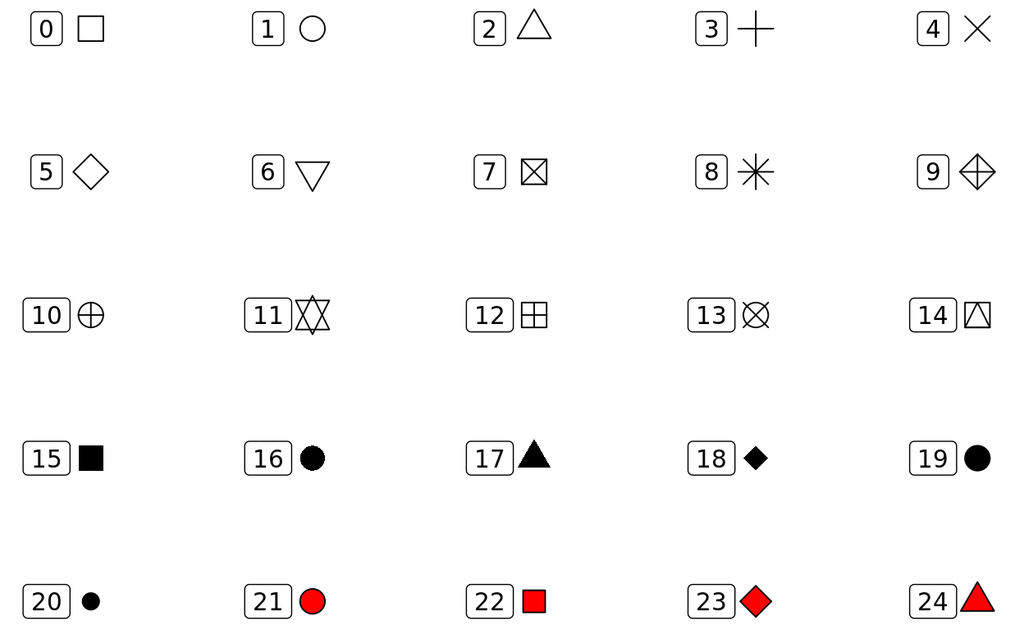

Create a plot of int3 vs int4 where color indicates trt, and shape indicates who measured the plant:

```
tomato %>% ggplot(mapping = aes(x=int3,y=int4, color = trt, shape = who)) +
  geom_point()
```

```
tomato %>% ggplot(mapping = aes(x=lon,y=alt, size = lat, color = species)) +
  geom_point()
```

**set plot characteristics without mapping**  
chage a plot characteristics but not have it mapped to a data column  
do this outside of the `aes` function:

```
tomato %>% ggplot(mapping = aes(x=petleng,y=leafleng)) +
  geom_point(color="skyblue")
```

Change the code below to use shape 2:

```
tomato %>% ggplot(mapping = aes(x=petleng,y=leafleng)) +
  geom_point(color="skyblue", shape = 2)
```

### Geoms

`geom_smooth` to add **trend lines** to the plots:

```
tomato %>% ggplot(aes(x=lon, y = lat)) +
  geom_smooth()
```

add multiple geoms to a plot (contain both dots and trendline):

```
tomato %>% ggplot(aes(x=lon, y = lat)) +
  geom_smooth() +
  geom_point()
```

show a best-fit, **straight linear regression**. `lm` stands for linear model:

```
tomato %>% ggplot(aes(x=lon, y = lat)) +
  geom_smooth(method="lm") +
  geom_point()
```

to create **historgram**. y-values are calculated for you, so only need x aesthetic:

```
tomato %>% ggplot(aes(x=hyp)) +
  geom_histogram()
```

`fill` the **histogram with color**:

```
tomato %>% ggplot(aes(x=hyp)) +
  geom_histogram(fill="red")
```

**density** plot (y-axis unit is different from histogram’s). a smooth trendline related to histogram plot:

```
tomato %>% ggplot(aes(x=hyp)) +
  geom_density()
```

`alpha` shows the transparancy of the color, which is range from 0-1.  
Compare the densities of different subsets of the data:

```
tomato %>% ggplot(aes(x=hyp, fill=trt)) +
  geom_density(alpha=.5)
```

Boxplots and violin plots provide quick summaries of different classes of data.  
**boxplot** to map hypocotyl length to the y-axis and species to the x-axis

```
tomato %>% ggplot(aes(x=species, y=hyp)) +
  geom_boxplot()
```

use `geom_violin()` fir **violin plot**

add a color or fill aesthetic to a box or violin plot then we can start comparing multiple factors in our data:

```
tomato %>% ggplot(aes(x=species, y=hyp, fill = trt)) +
  geom_boxplot()
```

**geom_col()** to make a classic bar chart summarize to get mean and error bars:

```
sem <- function(x, na.rm=FALSE) {
  sd(x,na.rm=na.rm)/sqrt(length(na.omit(x)))
}

int3.mean.sem <- tomato %>%
  group_by(species, trt) %>%
  summarize(mean=mean(int3, na.rm=TRUE), sem=sem(int3, na.rm=TRUE))

int3.mean.sem
```

then bar chart:

```
int3.mean.sem %>% ggplot(aes(x=species, y = mean, fill=trt)) +
  geom_col()
```

change the `position` of bars:

```
int3.mean.sem %>% ggplot(aes(x=species, y = mean, fill=trt)) +
  geom_col(position="dodge")
```

add error bars:

```
int3.mean.sem %>% ggplot(aes(x=species,
                             y = mean,
                             fill=trt,
                             ymax=mean+sem,
                             ymin=mean-sem)) +
  geom_col(position="dodge") +
  geom_errorbar(position = position_dodge(width=0.9), width=.5)
```

**geom_line()**

```
int3.mean.sem %>% ggplot(aes(x=species,
                             y=mean,
                             color=trt,
                             group=trt,
                             shape=trt,
                             ymax=mean+sem,
                             ymin=mean-sem)) +
  geom_line() +
  geom_errorbar(width=.1) +
  geom_point()
```

### Scales

`scale_fill_manual` to fill colors to be something else:

```
int3.mean.sem %>% ggplot(aes(x=species, y = mean, fill=trt, ymax=mean+sem, ymin=mean-sem)) +
  geom_col(position="dodge") +
  geom_errorbar(position = position_dodge(width=0.9), width=.5) +
  scale_fill_manual(values = c("H"="darkblue","L"="red"))
```

A particular useful one is `scale_y_log10()` that transforms the y-axis scale (there is an equivalent `scale_x_log10()`

### Facets

`facet_wrap()` uses a single variable for faceting and you can specify the number of rows or columns used in the layout:

```
tomato %>% ggplot(aes(x=int3)) +
  geom_density(fill="lightblue") +
  facet_wrap(~ trt)
```

facets are arranged in columns instead of rows:

```
tomato %>% ggplot(aes(x=hyp)) +
  geom_density(fill="papayawhip") +
  facet_wrap(~ trt, ncol = 1)
```

`facet_grid()` can use two variables to facet and uses those variable to specify the grid of rows and columns:

```
tomato %>% ggplot(aes(x=int3)) +
  geom_histogram(fill="lawngreen") +
  facet_grid(who ~ trt)
```

### Titles and Labels

use `ggtitle()` to add a main title to the plot, and `xlab()` and `ylab()` to change the axis labels.

```
tomato %>% ggplot(aes(x=species,y=int3,fill=trt)) +
  geom_boxplot() +
  ylab("Internode 3 (mm)") +
  xlab("Tomato Species") +
  ggtitle("tomato species and internode")
```

### Saving the plots

`ggsave()` to save your plot to an external file.  
R will figure out the appropriate file type from the file extension (pdf, png, jpg, tif). You can also specify height and width:

```
tomato %>% ggplot(aes(x=species,y=int3,fill=trt)) +
  geom_boxplot() +
  ylab("Internode 3 (mm)")
ggsave("~/Desktop/Internode3.pdf", height=6, width = 6)
```